# Misspecification for Technometrics

```python
%matplotlib inline
import numpy as np
import igraph as ig
from sft_net import *
from sft import *
import networkx as nx
from roc import *
from matplotlib import pyplot as plt
from adsy.display import extended_styles
extended_styles()
```

Toggle Input

## "Caterpillar Topology"

In this version of model misspecification, the attacker actually explores the network according to the caterpillar pattern. That is, when he infects a new node, he begins sending messages out to all connected nodes. However, in our "attacker model" we only assume the attacker traverses the center path. The rationale for this is that sometimes, we might have a network that is too large to develop an attacker model. Therefore, we might simply assign a rate of 0 to edges into a host that we are less concerned about but continue to monitor them and include them in our likelihood calculations. Below is a figure of the topology and the results.

The rate of clean message transmission is 1. The rate of malicious message transmission along the center path is .5 and the rate of malicious message transmission to the left and right nodes is .25.

```python
G = ig.Graph()
vertices = ['attacker'] + ['Machine']*12
G.add_vertices(vertices)
G.to_directed()
G.add_edges([(0,1), (0,2), (0,3), (2,4), (2,5), (2,6), (5,7), (5,8), (5,9), (8,10), (8,11), (8,12)])
G.vs['name'] = ['Attacker'] + ['User']*12
lout = G.layout_reingold_tilford(root=0)
coords = np.asarray(lout.coords)
#coords[-1,0] = 0
G.vs['x'] = list(coords[:,0])
G.vs['y'] = list(coords[:,1])
ig.plot(G, './technoextension1.png', autocurve=True, bbox= (400,400),margin=50,
        vertex_color = ['Red']+['rgb(0, 200, 200)']*12 , vertex_size=[30]+[17.5]*12,
        edge_arrow_size=.5,
        edge_arrow_width=2)
```

[figure not shown]

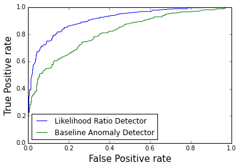

```python
# The true model
C1 = SFT('C1', ['normal' , 'infected'], ['L1', 'C2', 'R1'] ,
    {'L1': np.array([[1, 0], [1,.25]]),
     'C2': np.array([[1, 0], [1,.5]]),
     'R1': np.array([[1, 0], [1,.25]])},
    ['clean', 'malicious'], 'external')

L1 = SFT('L1', ['normal' , 'infected'], [] ,
    {},
    ['clean', 'malicious'], 'external')

R1 = SFT('R1', ['normal' , 'infected'], [] ,
    {},
    ['clean', 'malicious'], 'external')

C2 = SFT('C2', ['normal' , 'infected'], ['L2', 'C3', 'R2'] ,
    {'L2': np.array([[1, 0], [1,.25]]),
     'C3': np.array([[1, 0], [1,.5]]),
     'R2': np.array([[1, 0], [1,.25]])},
    ['clean', 'malicious'], 'external')

L2 = SFT('L2', ['normal' , 'infected'], [] ,
    {},
    ['clean', 'malicious'], 'external')

R2 = SFT('R2', ['normal' , 'infected'], [] ,
    {},
    ['clean', 'malicious'], 'external')

C3 = SFT('C3', ['normal' , 'infected'], ['L3', 'C4', 'R3'] ,
    {'L3': np.array([[1, 0], [1,.25]]),
     'C4': np.array([[1, 0], [1,.5]]),
     'R3': np.array([[1, 0], [1,.25]])},
    ['clean', 'malicious'], 'external')

L3 = SFT('L3', ['normal' , 'infected'], [] ,
    {},
    ['clean', 'malicious'], 'external')

R3 = SFT('R3', ['normal' , 'infected'], [] ,
    {},
    ['clean', 'malicious'], 'external')

C4 = SFT('C4', ['normal' , 'infected'], ['L4', 'C5', 'R4'] ,
    {'L4': np.array([[1, 0], [1,.25]]),
     'C5': np.array([[1, 0], [1,.5]]),
     'R4': np.array([[1, 0], [1,.25]])},
    ['clean', 'malicious'], 'external')

L4 = SFT('L4', ['normal' , 'infected'], [] ,
    {},
    ['clean', 'malicious'], 'external')

R4 = SFT('R4', ['normal' , 'infected'], [] ,
    {},
    ['clean', 'malicious'], 'external')

C5 = SFT('C5', ['normal' , 'infected'], [] ,
    {},
    ['clean', 'malicious'], 'external')

truenodes = [C1, R1, L1, C2, R2, L2, C3, R3, L3, C4,R4,L4,C5]
s0 = dict(zip(['C1', 'R1', 'L1', 'C2', 'R2', 'L2', 'C3', 'R3', 'L3', 'C4', 'R4', 'L4', 'C5'],
              ['normal']*13))
s0['C1']= 'infected'
truenet =SFTNet(truenodes)

# The assumed model


C1 = SFT('C1', ['normal' , 'infected'], ['C2'] ,
    {
     'C2': np.array([[1, 0], [1,.5]])},
    ['clean', 'malicious'], 'external')

L1 = SFT('L1', ['normal' , 'infected'], [] ,
    {},
    ['clean', 'malicious'], 'external')

R1 = SFT('R1', ['normal' , 'infected'], [] ,
    {},
    ['clean', 'malicious'], 'external')

C2 = SFT('C2', ['normal' , 'infected'], [ 'C3'] ,
    {
     'C3': np.array([[1, 0], [1,.5]])},
    ['clean', 'malicious'], 'external')

L2 = SFT('L2', ['normal' , 'infected'], [] ,
    {},
    ['clean', 'malicious'], 'external')

R2 = SFT('R2', ['normal' , 'infected'], [] ,
    {},
    ['clean', 'malicious'], 'external')

C3 = SFT('C3', ['normal' , 'infected'], [ 'C4'] ,
    {
     'C4': np.array([[1, 0], [1,.5]])},
    ['clean', 'malicious'], 'external')

L3 = SFT('L3', ['normal' , 'infected'], [] ,
    {},
    ['clean', 'malicious'], 'external')

R3 = SFT('R3', ['normal' , 'infected'], [] ,
    {},
    ['clean', 'malicious'], 'external')

C4 = SFT('C4', ['normal' , 'infected'], [ 'C5'] ,
    {
     'C5': np.array([[1, 0], [1,.5]])},
    ['clean', 'malicious'], 'external')

L4 = SFT('L4', ['normal' , 'infected'], [] ,
    {},
    ['clean', 'malicious'], 'external')

R4 = SFT('R4', ['normal' , 'infected'], [] ,
    {},
    ['clean', 'malicious'], 'external')

C5 = SFT('C5', ['normal' , 'infected'], [] ,
    {},
    ['clean', 'malicious'], 'external')

misspec_nodes = [C1, R1, L1, C2, R2, L2, C3, R3, L3, C4,R4,L4,C5]
misspecnet = SFTNet(misspec_nodes)
percore = 50
s_input = s0
def f1(x):
    return get_roc_coords(x, percore, percore, misspecnet, s0=s_input , truenet=truenet, \
                                  T=10, method='direct', directsamps=1000, printsteps=False)
from multiprocessing import Pool
p = Pool(8)
results1 = p.map(f1, list(np.random.randint(0, 20000, 8)))
pos_5, neg_5 = handle_parallel_res(results1)
our_roc_pts = np.asarray(plot_our_roc(pos_5, neg_5, .01))
anom_roc_pts = np.asarray(plot_anomaly_roc(pos_5, neg_5, .01))
plt.plot(our_roc_pts[:,0], our_roc_pts[:,1], label ='Likelihood Ratio Detector')
plt.plot(anom_roc_pts[:,0], anom_roc_pts[:,1], label = 'Baseline Anomaly Detector')
plt.xlim(0,1)
plt.ylabel('True Positive rate', fontsize=15)
plt.xlabel('False Positive rate', fontsize=15)
plt.legend(loc=0)
```

## Mean zero noise

In this experiment, I simply add mean zero noise to each of the rates of the true attacker model described above. The obvious reason for this model of misspecification is that we might, on average, know how the attacker will traverse the network but we will not know exactly. The standard distribution is 10% of the actual rate.

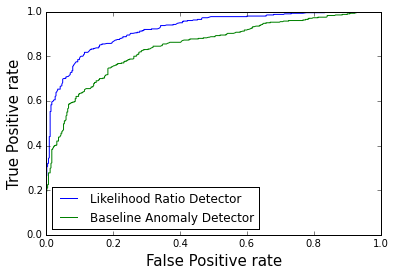

```python
# The true model
C1 = SFT('C1', ['normal' , 'infected'], ['L1', 'C2', 'R1'] ,
    {'L1': np.array([[1, 0], [1,.25]]),
     'C2': np.array([[1, 0], [1,.5]]),
     'R1': np.array([[1, 0], [1,.25]])},
    ['clean', 'malicious'], 'external')

L1 = SFT('L1', ['normal' , 'infected'], [] ,
    {},
    ['clean', 'malicious'], 'external')

R1 = SFT('R1', ['normal' , 'infected'], [] ,
    {},
    ['clean', 'malicious'], 'external')

C2 = SFT('C2', ['normal' , 'infected'], ['L2', 'C3', 'R2'] ,
    {'L2': np.array([[1, 0], [1,.25]]),
     'C3': np.array([[1, 0], [1,.5]]),
     'R2': np.array([[1, 0], [1,.25]])},
    ['clean', 'malicious'], 'external')

L2 = SFT('L2', ['normal' , 'infected'], [] ,
    {},
    ['clean', 'malicious'], 'external')

R2 = SFT('R2', ['normal' , 'infected'], [] ,
    {},
    ['clean', 'malicious'], 'external')

C3 = SFT('C3', ['normal' , 'infected'], ['L3', 'C4', 'R3'] ,
    {'L3': np.array([[1, 0], [1,.25]]),
     'C4': np.array([[1, 0], [1,.5]]),
     'R3': np.array([[1, 0], [1,.25]])},
    ['clean', 'malicious'], 'external')

L3 = SFT('L3', ['normal' , 'infected'], [] ,
    {},
    ['clean', 'malicious'], 'external')

R3 = SFT('R3', ['normal' , 'infected'], [] ,
    {},
    ['clean', 'malicious'], 'external')

C4 = SFT('C4', ['normal' , 'infected'], ['L4', 'C5', 'R4'] ,
    {'L4': np.array([[1, 0], [1,.25]]),
     'C5': np.array([[1, 0], [1,.5]]),
     'R4': np.array([[1, 0], [1,.25]])},
    ['clean', 'malicious'], 'external')

L4 = SFT('L4', ['normal' , 'infected'], [] ,
    {},
    ['clean', 'malicious'], 'external')

R4 = SFT('R4', ['normal' , 'infected'], [] ,
    {},
    ['clean', 'malicious'], 'external')

C5 = SFT('C5', ['normal' , 'infected'], [] ,
    {},
    ['clean', 'malicious'], 'external')

truenodes = [C1, R1, L1, C2, R2, L2, C3, R3, L3, C4,R4,L4,C5]
s0 = dict(zip(['C1', 'R1', 'L1', 'C2', 'R2', 'L2', 'C3', 'R3', 'L3', 'C4', 'R4', 'L4', 'C5'],
              ['normal']*13))
s0['C1']= 'infected'
truenet =SFTNet(truenodes)

C1 = SFT('C1', ['normal' , 'infected'], ['L1', 'C2', 'R1'] ,
    {'L1': np.array([[1, 0], [1,.25 + np.random.normal(0,.025)]]),
     'C2': np.array([[1, 0], [1,.5 + np.random.normal(0,.05)]]),
     'R1': np.array([[1, 0], [1,.25 + np.random.normal(0,.025) ]])},
    ['clean', 'malicious'], 'external')

L1 = SFT('L1', ['normal' , 'infected'], [] ,
    {},
    ['clean', 'malicious'], 'external')

R1 = SFT('R1', ['normal' , 'infected'], [] ,
    {},
    ['clean', 'malicious'], 'external')

C2 = SFT('C2', ['normal' , 'infected'], ['L2', 'C3', 'R2'] ,
    {'L2': np.array([[1, 0], [1,.25 + np.random.normal(0,.025) ]]),
     'C3': np.array([[1, 0], [1,.5+ np.random.normal(0,.05)]]),
     'R2': np.array([[1, 0], [1,.25 + np.random.normal(0,.025) ]])},
    ['clean', 'malicious'], 'external')

L2 = SFT('L2', ['normal' , 'infected'], [] ,
    {},
    ['clean', 'malicious'], 'external')

R2 = SFT('R2', ['normal' , 'infected'], [] ,
    {},
    ['clean', 'malicious'], 'external')

C3 = SFT('C3', ['normal' , 'infected'], ['L3', 'C4', 'R3'] ,
    {'L3': np.array([[1, 0], [1,.25 + np.random.normal(0,.025) ]]),
     'C4': np.array([[1, 0], [1,.5 + np.random.normal(0,.05) ]]),
     'R3': np.array([[1, 0], [1,.25 + np.random.normal(0,.025) ]])},
    ['clean', 'malicious'], 'external')

L3 = SFT('L3', ['normal' , 'infected'], [] ,
    {},
    ['clean', 'malicious'], 'external')

R3 = SFT('R3', ['normal' , 'infected'], [] ,
    {},
    ['clean', 'malicious'], 'external')

C4 = SFT('C4', ['normal' , 'infected'], ['L4', 'C5', 'R4'] ,
    {'L4': np.array([[1, 0], [1,.25 + np.random.normal(0,.025)]]),
     'C5': np.array([[1, 0], [1,.5 + np.random.normal(0,.05) ]]),
     'R4': np.array([[1, 0], [1,.25 + np.random.normal(0,.025)]])},
    ['clean', 'malicious'], 'external')

L4 = SFT('L4', ['normal' , 'infected'], [] ,
    {},
    ['clean', 'malicious'], 'external')

R4 = SFT('R4', ['normal' , 'infected'], [] ,
    {},
    ['clean', 'malicious'], 'external')

C5 = SFT('C5', ['normal' , 'infected'], [] ,
    {},
    ['clean', 'malicious'], 'external')


misspec_nodes = [C1, R1, L1, C2, R2, L2, C3, R3, L3, C4,R4,L4,C5]
misspecnet = SFTNet(misspec_nodes)

def f1(x):
    return get_roc_coords(x, percore, percore, misspecnet, s0=s_input , truenet=truenet, \
                                  T=10, method='direct', directsamps=1000, printsteps=False)

from multiprocessing import Pool
p = Pool(8)
results1 = p.map(f1, list(np.random.randint(0, 20000, 8)))
pos_5, neg_5 = handle_parallel_res(results1)
our_roc_pts = np.asarray(plot_our_roc(pos_5, neg_5, .01))
anom_roc_pts = np.asarray(plot_anomaly_roc(pos_5, neg_5, .01))
plt.plot(our_roc_pts[:,0], our_roc_pts[:,1], label ='Likelihood Ratio Detector')
plt.plot(anom_roc_pts[:,0], anom_roc_pts[:,1], label = 'Baseline Anomaly Detector')
plt.xlim(0,1)
plt.ylabel('True Positive rate', fontsize=15)
plt.xlabel('False Positive rate', fontsize=15)
plt.legend(loc=0)
```

Now we raise the standard deviation of the disturbance to 20% of the actual rates

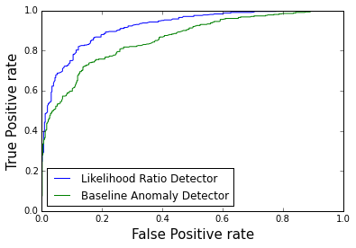

```python
# The true model
C1 = SFT('C1', ['normal' , 'infected'], ['L1', 'C2', 'R1'] ,
    {'L1': np.array([[1, 0], [1,.25]]),
     'C2': np.array([[1, 0], [1,.5]]),
     'R1': np.array([[1, 0], [1,.25]])},
    ['clean', 'malicious'], 'external')

L1 = SFT('L1', ['normal' , 'infected'], [] ,
    {},
    ['clean', 'malicious'], 'external')

R1 = SFT('R1', ['normal' , 'infected'], [] ,
    {},
    ['clean', 'malicious'], 'external')

C2 = SFT('C2', ['normal' , 'infected'], ['L2', 'C3', 'R2'] ,
    {'L2': np.array([[1, 0], [1,.25]]),
     'C3': np.array([[1, 0], [1,.5]]),
     'R2': np.array([[1, 0], [1,.25]])},
    ['clean', 'malicious'], 'external')

L2 = SFT('L2', ['normal' , 'infected'], [] ,
    {},
    ['clean', 'malicious'], 'external')

R2 = SFT('R2', ['normal' , 'infected'], [] ,
    {},
    ['clean', 'malicious'], 'external')

C3 = SFT('C3', ['normal' , 'infected'], ['L3', 'C4', 'R3'] ,
    {'L3': np.array([[1, 0], [1,.25]]),
     'C4': np.array([[1, 0], [1,.5]]),
     'R3': np.array([[1, 0], [1,.25]])},
    ['clean', 'malicious'], 'external')

L3 = SFT('L3', ['normal' , 'infected'], [] ,
    {},
    ['clean', 'malicious'], 'external')

R3 = SFT('R3', ['normal' , 'infected'], [] ,
    {},
    ['clean', 'malicious'], 'external')

C4 = SFT('C4', ['normal' , 'infected'], ['L4', 'C5', 'R4'] ,
    {'L4': np.array([[1, 0], [1,.25]]),
     'C5': np.array([[1, 0], [1,.5]]),
     'R4': np.array([[1, 0], [1,.25]])},
    ['clean', 'malicious'], 'external')

L4 = SFT('L4', ['normal' , 'infected'], [] ,
    {},
    ['clean', 'malicious'], 'external')

R4 = SFT('R4', ['normal' , 'infected'], [] ,
    {},
    ['clean', 'malicious'], 'external')

C5 = SFT('C5', ['normal' , 'infected'], [] ,
    {},
    ['clean', 'malicious'], 'external')

truenodes = [C1, R1, L1, C2, R2, L2, C3, R3, L3, C4,R4,L4,C5]
s0 = dict(zip(['C1', 'R1', 'L1', 'C2', 'R2', 'L2', 'C3', 'R3', 'L3', 'C4', 'R4', 'L4', 'C5'],
              ['normal']*13))
s0['C1']= 'infected'
truenet =SFTNet(truenodes)

C1 = SFT('C1', ['normal' , 'infected'], ['L1', 'C2', 'R1'] ,
    {'L1': np.array([[1, 0], [1,.25 + np.random.normal(0,.05)]]),
     'C2': np.array([[1, 0], [1,.5 + np.random.normal(0,.1)]]),
     'R1': np.array([[1, 0], [1,.25 + np.random.normal(0,.05) ]])},
    ['clean', 'malicious'], 'external')

L1 = SFT('L1', ['normal' , 'infected'], [] ,
    {},
    ['clean', 'malicious'], 'external')

R1 = SFT('R1', ['normal' , 'infected'], [] ,
    {},
    ['clean', 'malicious'], 'external')

C2 = SFT('C2', ['normal' , 'infected'], ['L2', 'C3', 'R2'] ,
    {'L2': np.array([[1, 0], [1,.25 + np.random.normal(0,.05) ]]),
     'C3': np.array([[1, 0], [1,.5+ np.random.normal(0,.1)]]),
     'R2': np.array([[1, 0], [1,.25 + np.random.normal(0,.05) ]])},
    ['clean', 'malicious'], 'external')

L2 = SFT('L2', ['normal' , 'infected'], [] ,
    {},
    ['clean', 'malicious'], 'external')

R2 = SFT('R2', ['normal' , 'infected'], [] ,
    {},
    ['clean', 'malicious'], 'external')

C3 = SFT('C3', ['normal' , 'infected'], ['L3', 'C4', 'R3'] ,
    {'L3': np.array([[1, 0], [1,.25 + np.random.normal(0,.5) ]]),
     'C4': np.array([[1, 0], [1,.5 + np.random.normal(0,.1) ]]),
     'R3': np.array([[1, 0], [1,.25 + np.random.normal(0,.05) ]])},
    ['clean', 'malicious'], 'external')

L3 = SFT('L3', ['normal' , 'infected'], [] ,
    {},
    ['clean', 'malicious'], 'external')

R3 = SFT('R3', ['normal' , 'infected'], [] ,
    {},
    ['clean', 'malicious'], 'external')

C4 = SFT('C4', ['normal' , 'infected'], ['L4', 'C5', 'R4'] ,
    {'L4': np.array([[1, 0], [1,.25 + np.random.normal(0,.05)]]),
     'C5': np.array([[1, 0], [1,.5 + np.random.normal(0,.1) ]]),
     'R4': np.array([[1, 0], [1,.25 + np.random.normal(0,.05)]])},
    ['clean', 'malicious'], 'external')

L4 = SFT('L4', ['normal' , 'infected'], [] ,
    {},
    ['clean', 'malicious'], 'external')

R4 = SFT('R4', ['normal' , 'infected'], [] ,
    {},
    ['clean', 'malicious'], 'external')

C5 = SFT('C5', ['normal' , 'infected'], [] ,
    {},
    ['clean', 'malicious'], 'external')


misspec_nodes = [C1, R1, L1, C2, R2, L2, C3, R3, L3, C4,R4,L4,C5]
misspecnet = SFTNet(misspec_nodes)
def f1(x):
    return get_roc_coords(x, percore, percore, misspecnet, s0=s_input , truenet=truenet, \
                                  T=10, method='direct', directsamps=1000, printsteps=False)
from multiprocessing import Pool
p = Pool(8)
results1 = p.map(f1, list(np.random.randint(0, 20000, 8)))
pos_5, neg_5 = handle_parallel_res(results1)
our_roc_pts = np.asarray(plot_our_roc(pos_5, neg_5, .01))
anom_roc_pts = np.asarray(plot_anomaly_roc(pos_5, neg_5, .01))
plt.plot(our_roc_pts[:,0], our_roc_pts[:,1], label ='Likelihood Ratio Detector')
plt.plot(anom_roc_pts[:,0], anom_roc_pts[:,1], label = 'Baseline Anomaly Detector')
plt.xlim(0,1)
plt.ylabel('True Positive rate', fontsize=15)
plt.xlabel('False Positive rate', fontsize=15)
plt.legend(loc=0)
```

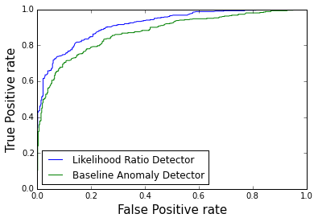

```python
# The true model
C1 = SFT('C1', ['normal' , 'infected'], ['L1', 'C2', 'R1'] ,
    {'L1': np.array([[1, 0], [1,.25]]),
     'C2': np.array([[1, 0], [1,.5]]),
     'R1': np.array([[1, 0], [1,.25]])},
    ['clean', 'malicious'], 'external')

L1 = SFT('L1', ['normal' , 'infected'], [] ,
    {},
    ['clean', 'malicious'], 'external')

R1 = SFT('R1', ['normal' , 'infected'], [] ,
    {},
    ['clean', 'malicious'], 'external')

C2 = SFT('C2', ['normal' , 'infected'], ['L2', 'C3', 'R2'] ,
    {'L2': np.array([[1, 0], [1,.25]]),
     'C3': np.array([[1, 0], [1,.5]]),
     'R2': np.array([[1, 0], [1,.25]])},
    ['clean', 'malicious'], 'external')

L2 = SFT('L2', ['normal' , 'infected'], [] ,
    {},
    ['clean', 'malicious'], 'external')

R2 = SFT('R2', ['normal' , 'infected'], [] ,
    {},
    ['clean', 'malicious'], 'external')

C3 = SFT('C3', ['normal' , 'infected'], ['L3', 'C4', 'R3'] ,
    {'L3': np.array([[1, 0], [1,.25]]),
     'C4': np.array([[1, 0], [1,.5]]),
     'R3': np.array([[1, 0], [1,.25]])},
    ['clean', 'malicious'], 'external')

L3 = SFT('L3', ['normal' , 'infected'], [] ,
    {},
    ['clean', 'malicious'], 'external')

R3 = SFT('R3', ['normal' , 'infected'], [] ,
    {},
    ['clean', 'malicious'], 'external')

C4 = SFT('C4', ['normal' , 'infected'], ['L4', 'C5', 'R4'] ,
    {'L4': np.array([[1, 0], [1,.25]]),
     'C5': np.array([[1, 0], [1,.5]]),
     'R4': np.array([[1, 0], [1,.25]])},
    ['clean', 'malicious'], 'external')

L4 = SFT('L4', ['normal' , 'infected'], [] ,
    {},
    ['clean', 'malicious'], 'external')

R4 = SFT('R4', ['normal' , 'infected'], [] ,
    {},
    ['clean', 'malicious'], 'external')

C5 = SFT('C5', ['normal' , 'infected'], [] ,
    {},
    ['clean', 'malicious'], 'external')

truenodes = [C1, R1, L1, C2, R2, L2, C3, R3, L3, C4,R4,L4,C5]
s0 = dict(zip(['C1', 'R1', 'L1', 'C2', 'R2', 'L2', 'C3', 'R3', 'L3', 'C4', 'R4', 'L4', 'C5'],
              ['normal']*13))
s0['C1']= 'infected'
truenet =SFTNet(truenodes)

C1 = SFT('C1', ['normal' , 'infected'], ['L1', 'C2', 'R1'] ,
    {'L1': np.array([[1, 0], [1,.25 + np.random.normal(0,.05)]]),
     'C2': np.array([[1, 0], [1,.5 + np.random.normal(0,.1)]]),
     'R1': np.array([[1, 0], [1,.25 + np.random.normal(0,.05) ]])},
    ['clean', 'malicious'], 'external')

L1 = SFT('L1', ['normal' , 'infected'], [] ,
    {},
    ['clean', 'malicious'], 'external')

R1 = SFT('R1', ['normal' , 'infected'], [] ,
    {},
    ['clean', 'malicious'], 'external')

C2 = SFT('C2', ['normal' , 'infected'], ['L2', 'C3', 'R2'] ,
    {'L2': np.array([[1, 0], [1,.25 + np.random.normal(0,.05) ]]),
     'C3': np.array([[1, 0], [1,.5+ np.random.normal(0,.1)]]),
     'R2': np.array([[1, 0], [1,.25 + np.random.normal(0,.05) ]])},
    ['clean', 'malicious'], 'external')

L2 = SFT('L2', ['normal' , 'infected'], [] ,
    {},
    ['clean', 'malicious'], 'external')

R2 = SFT('R2', ['normal' , 'infected'], [] ,
    {},
    ['clean', 'malicious'], 'external')

C3 = SFT('C3', ['normal' , 'infected'], ['L3', 'C4', 'R3'] ,
    {'L3': np.array([[1, 0], [1,.25 + np.random.normal(0,.5) ]]),
     'C4': np.array([[1, 0], [1,.5 + np.random.normal(0,.1) ]]),
     'R3': np.array([[1, 0], [1,.25 + np.random.normal(0,.05) ]])},
    ['clean', 'malicious'], 'external')

L3 = SFT('L3', ['normal' , 'infected'], [] ,
    {},
    ['clean', 'malicious'], 'external')

R3 = SFT('R3', ['normal' , 'infected'], [] ,
    {},
    ['clean', 'malicious'], 'external')

C4 = SFT('C4', ['normal' , 'infected'], ['L4', 'C5', 'R4'] ,
    {'L4': np.array([[1, 0], [1,.25 + np.random.normal(0,.05)]]),
     'C5': np.array([[1, 0], [1,.5 + np.random.normal(0,.1) ]]),
     'R4': np.array([[1, 0], [1,.25 + np.random.normal(0,.05)]])},
    ['clean', 'malicious'], 'external')

L4 = SFT('L4', ['normal' , 'infected'], [] ,
    {},
    ['clean', 'malicious'], 'external')

R4 = SFT('R4', ['normal' , 'infected'], [] ,
    {},
    ['clean', 'malicious'], 'external')

C5 = SFT('C5', ['normal' , 'infected'], [] ,
    {},
    ['clean', 'malicious'], 'external')


misspec_nodes = [C1, R1, L1, C2, R2, L2, C3, R3, L3, C4,R4,L4,C5]
misspecnet = SFTNet(misspec_nodes)
def f1(x):
    return get_roc_coords(x, percore, percore, misspecnet, s0=s_input , truenet=truenet, \
                                  T=10, method='direct', directsamps=1000, printsteps=False)
from multiprocessing import Pool
p = Pool(8)
results1 = p.map(f1, list(np.random.randint(0, 20000, 8)))
pos_5, neg_5 = handle_parallel_res(results1)
our_roc_pts = np.asarray(plot_our_roc(pos_5, neg_5, .01))
anom_roc_pts = np.asarray(plot_anomaly_roc(pos_5, neg_5, .01))
plt.plot(our_roc_pts[:,0], our_roc_pts[:,1], label ='Likelihood Ratio Detector')
plt.plot(anom_roc_pts[:,0], anom_roc_pts[:,1], label = 'Baseline Anomaly Detector')
plt.xlim(0,1)
plt.ylabel('True Positive rate', fontsize=15)
plt.xlabel('False Positive rate', fontsize=15)
plt.legend(loc=0)
```